# OpenIntroR

William Han

11/17/2021

```r
library(tidyverse)
library(openintro)
library(janitor)
library(tidytuesdayR)
library(gapminder)
library(usdata)
```

# 1 Hello Data

```r
data(stent30)
data(stent365)

stent365 |>
  filter(group == "treatment") |>
  count(outcome == "stroke") |>
  mutate(prop = n/sum(n))
```

```
## # A tibble: 2 × 3
##   `outcome == "stroke"`     n  prop
##   <lgl>                 <int> <dbl>
## 1 FALSE                   179 0.799
## 2 TRUE                     45 0.201
```

```r
stent365 |>
  filter(group == "control") |>
  count(outcome == "stroke") |>
  mutate(prop = n/sum(n))
```

```
## # A tibble: 2 × 3
##   `outcome == "stroke"`     n  prop
##   <lgl>                 <int> <dbl>
## 1 FALSE                   199 0.877
## 2 TRUE                     28 0.123
```

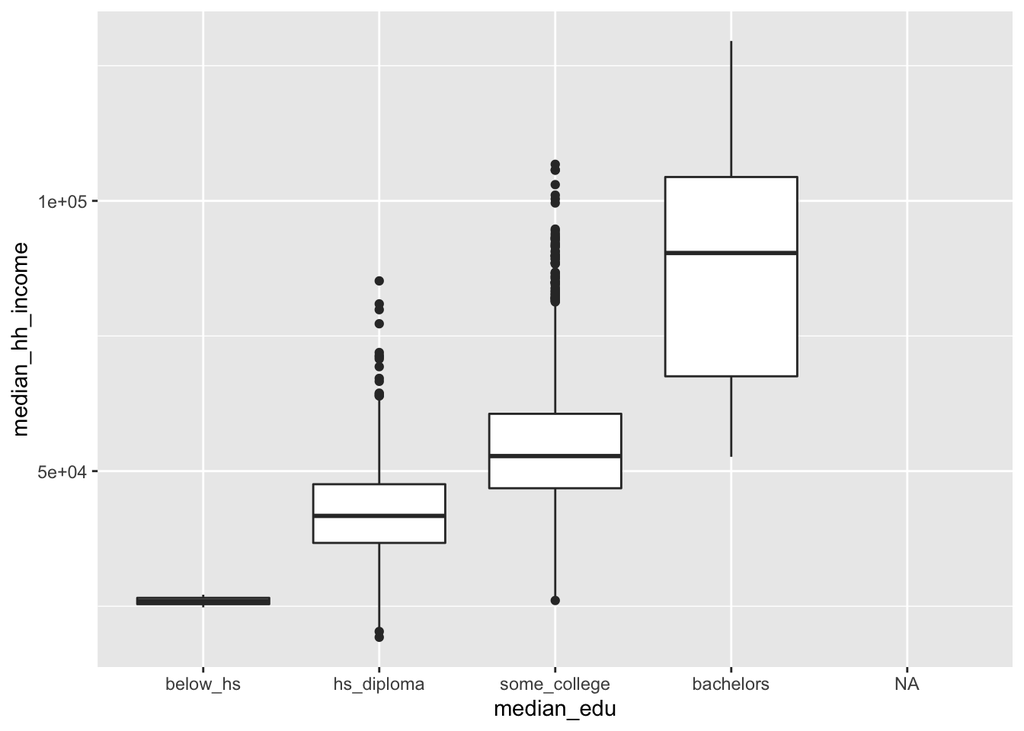

```r
data("loan50")
data("county")


ggplot(data = county,
       aes(x = median_edu,
           y = median_hh_income)) +
  geom_boxplot()
```

Question for loan50 data set: 1. Does higher credit usage positively correlate with bigger loan amounts?

Exercises (odd)

1. 23 observations / 6 variables
2. 1. What is the relationships between air pollutants and preterm births? Does air pollutant exposure have an association with preterm births?
2. The subjects are the births. There are 143,196 subjects.
3. The variables of this study are levels of carbon monoxide, nitrogen dioxide, ozone, and coarse particulate matter. all numerical continous variables
5. 1. the main research question of the study is what is the effect of gamification in educational activities/performance
2. the subjects of the study were students. there were 365 students.
3. The variables in this study were gender (categorical), level of studies (categorical, ordinal), academic major (categorical), expertise in English language (ordinal, categorical, ordinal), use of personal comp or games (categorical, ordinal),
7. 1. 23.26%

```r
10/43
```

```
## [1] 0.2325581
```

2. 4.35%

```r
2/46
```

```
## [1] 0.04347826
```

3. The treatment group
4. chance
5. explanatory - acupuncture or not variable - pain free or not
9. 1. this is an experiment because the researchers are looking at the effect of a fine on parents’ behavior related to picking up their child from daycare
2. each case is the daycare center and there are 10 daycare.
3. the response variable is the late pick up rate. This is a discrete numerical variable
4. the explanatory variables are the study period (categorical,ordinal), late pick ups (discrete numerical), group (categorical), week (discrete numerical).
11. 1. 344 cases
2. The bill length (continuous), bill depth(continuous), flipper length (continuous), and body mass (continuous) are all numerical variables.
3. The islands, species, and sex of penguins are categorical.
13. Region (categorical), Private and public use (categorical), airports (numerical, discrete), private and public ownership (categorical), longitude and latitude (numerical, continuous)
14. Nation (categorical), Year (numerical, discrete), number of babies (numerical, discrete)
15. 1. County, State, Race/Ethnicity, driver stopped or not, arrested or not, searched or not.
2. All categorical
3. race - explanatory variable and search rate - response variable
19. 1. observational study
2. Lucy - dog and Luna - cat
3. Lily, Oliver
4. Positive, as cats names get popular so does dogs.

# 2 Study Design

Cluster or Multistage sampling are most helpful when there is a lot of case to case variability within a cluster but the clusters themselves don’t look very different from one another.

Psuedoreplication occurs when individual observations under different treatments are heavily dependent on each other.

1. 1. $52 - population mean $58 - sample mean b.3.37 - population mean 3.59 - sample mean
2. 1. population - all births sample - 143,196 births in Southern CA
   2. If the births in this time span (1989 - 1993) and location (Southern CA) are representative of all births, then we can generalize the results to all of the births in SoCal. However, since this is a observational study, it cannot establish causal relationships.
3. 1. population - college students learning statistics sample - 365 college students in a statistics course
   2. If the 365 college students are representative of all college students studying statistics, then it can be generalized to the population. The findings can be used to establish causal relationships because it was an experimental study.
4. 1. observation
   2. variable
   3. sample statistic
   4. population parameter
5. 1. observational
   2. stratified sampling. Randomly sample a fixed amount of students , for example 10 students, from each section to get a sample of 40 students.
6. 1. There is a positive, nonlinear, somewhat strong correlation between life expectancy and percentage of internet users.
   2. observational
   3. A confounding variable may be the country’s wealth. A wealthy country would most likely have the resources to provide internet to many people as well as other resources, such as better healthcare, food, and water, resulting in longer life expectancy.
7. 1. Reasonable. It is a very rare instance for a simple random sampling method to not be okay.
   2. Students may have different opinions across a variety of fields, so this is reasonable.
   3. Students of similar age probably have similar opinions. We want the clusters to be diverse with respect to the outcome of interest, so this would not be a good approach.
8. 1. 200 randomply sampled men and women.
   2. The response variable is the people’s attitudes towards the microwave oven.
   3. The explanatory variable is the people’s attitude towards the subjects.
   4. Yes the study employed random sampling through using Amazon’s Mechanical Turk.
   5. Observation study because it there was no random assignment to treatments.
   6. We cannot establish a causal link
   7. If the 200 randomly sampled participants are representative of the total population, then it may be generalized. Since the study is random, we are able to generalize.
9. 1. Simple random sampling, non-response bias. People who may have a strong opinion on the subject may fill out the survey.
   2. Convenience sampling, under coverage bias. The sample is not representative of the whole population.
   3. Convenience sampling, ” ”
   4. Multi-stage sampling, potential non response variable.
10. 1. response variable - exam performance
    2. explanatory variable - light levels. The levels are fluorescent overhead lighting, yellow overhead lighting, no overhead lighting (only desk lamps)
    3. The blocking variables are people who wear glasses and people who don’t.
11. 1. experimental study
    2. 2 factors: Light level (fluorescent overhead lighting, yellow overhead lighting, no overhead lighting (only desk lamps) and noise (no noise, construction noise, and human chatter noise).
    3. blocking variable
12. The experiment needs to be blind and randomized. I would randomly distribute one cup filled with Coke and another with Diet Coke for each classmate. The cup filled with Coke would be labeled as (A) and the Diet Coke would be labeled as (B).
13. 1. experimental
    2. experimental treatment: group given 25 grams of chia seeds control treatment: group given placebo.
    3. Yes, gender
    4. Blinding was used. The groups were blinded on the treatment that they were given.
    5. We can make a causal statement, but since the study was not randomized, we cannot generalize the conclusion to the population stage.
14. 1. This is an observational study, so no causal inference can be made. There is also a non response bias. There is bias in the respondents because no parent would want to say that it is difficult to spend time with kids after school.
    2. The 567 women cannot be generalized to the 1000 women. Not a random study.
    3. There is no control group.
15. 1. Experimental
    2. Explanatory - consumption of fruits and vegetables. Response - psychological well being
    3. The results can not be generalized because the participants were volunteers.
    4. The results of the study can be used to establish a causal relationship
    5. The results of this study indicate a positive relationship in giving young adults fresh fruits and vegetables to eat and psychological well being.

# 3 Applications: Data

```r
passwords <- readr::read_csv('https://raw.githubusercontent.com/rfordatascience/tidytuesday/master/data/2020/2020-01-14/passwords.csv')
glimpse(passwords)
```

```
## Rows: 507
## Columns: 9
## $ rank              <dbl> 1, 2, 3, 4, 5, 6, 7, 8, 9, 10, 11, 12, 13, 14, 15, 1…
## $ password          <chr> "password", "123456", "12345678", "1234", "qwerty", …
## $ category          <chr> "password-related", "simple-alphanumeric", "simple-a…
## $ value             <dbl> 6.91, 18.52, 1.29, 11.11, 3.72, 1.85, 3.72, 6.91, 6.…
## $ time_unit         <chr> "years", "minutes", "days", "seconds", "days", "minu…
## $ offline_crack_sec <dbl> 2.170e+00, 1.110e-05, 1.110e-03, 1.110e-07, 3.210e-0…
## $ rank_alt          <dbl> 1, 2, 3, 4, 5, 6, 7, 8, 9, 10, 11, 12, 13, 14, 15, 1…
## $ strength          <dbl> 8, 4, 4, 4, 8, 4, 8, 4, 7, 8, 8, 1, 32, 9, 9, 8, 8, …
## $ font_size         <dbl> 11, 8, 8, 8, 11, 8, 11, 8, 11, 11, 11, 4, 23, 12, 12…
```

3.2 Interactive R Tutorials

```r
data('hsb2')

glimpse(hsb2)
```

```
## Rows: 200
## Columns: 11
## $ id      <int> 70, 121, 86, 141, 172, 113, 50, 11, 84, 48, 75, 60, 95, 104, 3…
## $ gender  <chr> "male", "female", "male", "male", "male", "male", "male", "mal…
## $ race    <chr> "white", "white", "white", "white", "white", "white", "african…
## $ ses     <fct> low, middle, high, high, middle, middle, middle, middle, middl…
## $ schtyp  <fct> public, public, public, public, public, public, public, public…
## $ prog    <fct> general, vocational, general, vocational, academic, academic, …
## $ read    <int> 57, 68, 44, 63, 47, 44, 50, 34, 63, 57, 60, 57, 73, 54, 45, 42…
## $ write   <int> 52, 59, 33, 44, 52, 52, 59, 46, 57, 55, 46, 65, 60, 63, 57, 49…
## $ math    <int> 41, 53, 54, 47, 57, 51, 42, 45, 54, 52, 51, 51, 71, 57, 50, 43…
## $ science <int> 47, 63, 58, 53, 53, 63, 53, 39, 58, 50, 53, 63, 61, 55, 31, 50…
## $ socst   <int> 57, 61, 31, 56, 61, 61, 61, 36, 51, 51, 61, 61, 71, 46, 56, 56…
```

```r
data('email50')

glimpse(email50)
```

```
## Rows: 50
## Columns: 21
## $ spam         <fct> 0, 0, 1, 0, 0, 0, 0, 0, 0, 0, 0, 0, 1, 1, 0, 0, 0, 1, 0, …
## $ to_multiple  <fct> 0, 0, 0, 0, 0, 0, 0, 0, 0, 0, 0, 0, 0, 1, 0, 0, 0, 0, 0, …
## $ from         <fct> 1, 1, 1, 1, 1, 1, 1, 1, 1, 1, 1, 1, 1, 1, 1, 1, 1, 1, 1, …
## $ cc           <int> 0, 0, 4, 0, 0, 0, 0, 0, 1, 0, 0, 0, 0, 0, 0, 0, 0, 0, 1, …
## $ sent_email   <fct> 1, 0, 0, 0, 0, 0, 0, 1, 1, 0, 0, 0, 0, 0, 0, 1, 1, 0, 1, …
## $ time         <dttm> 2012-01-04 05:19:16, 2012-02-16 12:10:06, 2012-01-04 07:…
## $ image        <dbl> 0, 0, 0, 0, 0, 0, 0, 0, 0, 0, 0, 0, 0, 0, 0, 0, 0, 0, 0, …
## $ attach       <dbl> 0, 0, 2, 0, 0, 0, 0, 0, 0, 0, 0, 0, 0, 2, 0, 0, 0, 1, 0, …
## $ dollar       <dbl> 0, 0, 0, 0, 9, 0, 0, 0, 0, 23, 4, 0, 3, 2, 0, 0, 0, 0, 0,…
## $ winner       <fct> no, no, no, no, no, no, no, no, no, no, no, no, yes, no, …
## $ inherit      <dbl> 0, 0, 0, 0, 0, 0, 0, 0, 0, 0, 0, 0, 0, 0, 0, 0, 0, 0, 0, …
## $ viagra       <dbl> 0, 0, 0, 0, 0, 0, 0, 0, 0, 0, 0, 0, 0, 0, 0, 0, 0, 0, 0, …
## $ password     <dbl> 0, 0, 0, 0, 1, 0, 0, 0, 0, 0, 0, 2, 0, 0, 0, 0, 0, 0, 8, …
## $ num_char     <dbl> 21.705, 7.011, 0.631, 2.454, 41.623, 0.057, 0.809, 5.229,…
## $ line_breaks  <int> 551, 183, 28, 61, 1088, 5, 17, 88, 242, 578, 1167, 198, 7…
## $ format       <fct> 1, 1, 0, 0, 1, 0, 0, 1, 1, 1, 1, 1, 1, 0, 1, 1, 1, 0, 1, …
## $ re_subj      <fct> 1, 0, 0, 0, 0, 0, 0, 1, 1, 0, 0, 0, 0, 0, 0, 1, 1, 0, 0, …
## $ exclaim_subj <dbl> 0, 0, 0, 0, 0, 0, 0, 0, 1, 0, 0, 0, 0, 0, 0, 0, 0, 0, 0, …
## $ urgent_subj  <fct> 0, 0, 0, 0, 0, 0, 0, 0, 0, 0, 0, 0, 0, 0, 0, 0, 0, 0, 0, …
## $ exclaim_mess <dbl> 8, 1, 2, 1, 43, 0, 0, 2, 22, 3, 13, 1, 2, 2, 21, 10, 0, 0…
## $ number       <fct> small, big, none, small, small, small, small, small, smal…
```

```r
nrow(email50)
```

```
## [1] 50
```

```r
ncol(email50)
```

```
## [1] 21
```

Using ?email50 I found detailed information of the following variables: spam - categorical to_multiple - categorical from - categorical cc - numerical, discrete sent_email - categorical time - categorical, ordinal etc.

```r
hsb2 |>
  count(schtyp)
```

```
## # A tibble: 2 × 2
##   schtyp      n
##   <fct>   <int>
## 1 public    168
## 2 private    32
```

```r
sum(3, 4)
```

```
## [1] 7
```

```r
3 |>
  sum(4)
```

```
## [1] 7
```

```r
hsb2_public <- hsb2 |>
  filter(schtyp == 'public')

hsb2_public |>
  count(schtyp)
```

```
## # A tibble: 1 × 2
##   schtyp     n
##   <fct>  <int>
## 1 public   168
```

```r
email50_big <- email50 |>
  filter(number == 'big')

glimpse(email50_big)
```

```
## Rows: 7
## Columns: 21
## $ spam         <fct> 0, 0, 1, 0, 0, 0, 0
## $ to_multiple  <fct> 0, 0, 0, 0, 0, 0, 0
## $ from         <fct> 1, 1, 1, 1, 1, 1, 1
## $ cc           <int> 0, 0, 0, 0, 0, 0, 0
## $ sent_email   <fct> 0, 0, 0, 0, 0, 1, 0
## $ time         <dttm> 2012-02-16 12:10:06, 2012-02-04 15:26:09, 2012-01-24 08:1…
## $ image        <dbl> 0, 0, 0, 0, 0, 0, 0
## $ attach       <dbl> 0, 0, 0, 0, 0, 0, 0
## $ dollar       <dbl> 0, 0, 3, 2, 0, 0, 0
## $ winner       <fct> no, no, yes, no, no, no, no
## $ inherit      <dbl> 0, 0, 0, 0, 0, 0, 0
## $ viagra       <dbl> 0, 0, 0, 0, 0, 0, 0
## $ password     <dbl> 0, 2, 0, 0, 0, 0, 8
## $ num_char     <dbl> 7.011, 10.368, 42.793, 26.520, 6.563, 11.223, 10.613
## $ line_breaks  <int> 183, 198, 712, 692, 140, 512, 225
## $ format       <fct> 1, 1, 1, 1, 1, 1, 1
## $ re_subj      <fct> 0, 0, 0, 0, 0, 0, 0
## $ exclaim_subj <dbl> 0, 0, 0, 1, 0, 0, 0
## $ urgent_subj  <fct> 0, 0, 0, 0, 0, 0, 0
## $ exclaim_mess <dbl> 1, 1, 2, 7, 2, 9, 9
## $ number       <fct> big, big, big, big, big, big, big
```

```r
mean(hsb2$read)
```

```
## [1] 52.23
```

```r
(avg_read <- mean(hsb2$read))
```

```
## [1] 52.23
```

```r
hsb2 <- hsb2 |>
  mutate(read_cat = if_else(read < avg_read,
                            "below average", "at or above average"))

hsb2
```

```
## # A tibble: 200 × 12
##       id gender race        ses   schtyp prog     read write  math science socst
##    <int> <chr>  <chr>       <fct> <fct>  <fct>   <int> <int> <int>   <int> <int>
##  1    70 male   white       low   public general    57    52    41      47    57
##  2   121 female white       midd… public vocati…    68    59    53      63    61
##  3    86 male   white       high  public general    44    33    54      58    31
##  4   141 male   white       high  public vocati…    63    44    47      53    56
##  5   172 male   white       midd… public academ…    47    52    57      53    61
##  6   113 male   white       midd… public academ…    44    52    51      63    61
##  7    50 male   african am… midd… public general    50    59    42      53    61
##  8    11 male   hispanic    midd… public academ…    34    46    45      39    36
##  9    84 male   white       midd… public general    63    57    54      58    51
## 10    48 male   african am… midd… public academ…    57    55    52      50    51
## # … with 190 more rows, and 1 more variable: read_cat <chr>
```

```r
med_num_char <- median(email50$num_char)

email50_updated <- email50 |>
  mutate(num_char_cat = if_else(num_char < med_num_char,
                                'below median',
                                'at or above median'))

email50_updated |>
  count(num_char_cat)
```

```
## # A tibble: 2 × 2
##   num_char_cat           n
##   <chr>              <int>
## 1 at or above median    25
## 2 below median          25
```

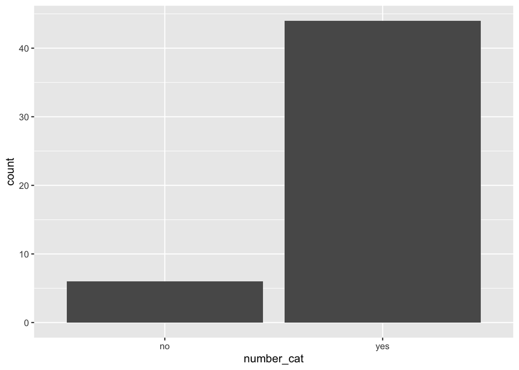

```r
email50_updated <- email50 |>
  mutate(number_cat = if_else(number == "none",
                              "no",
                              "yes"))

ggplot(email50_updated, aes(x = number_cat)) +
  geom_bar()
```

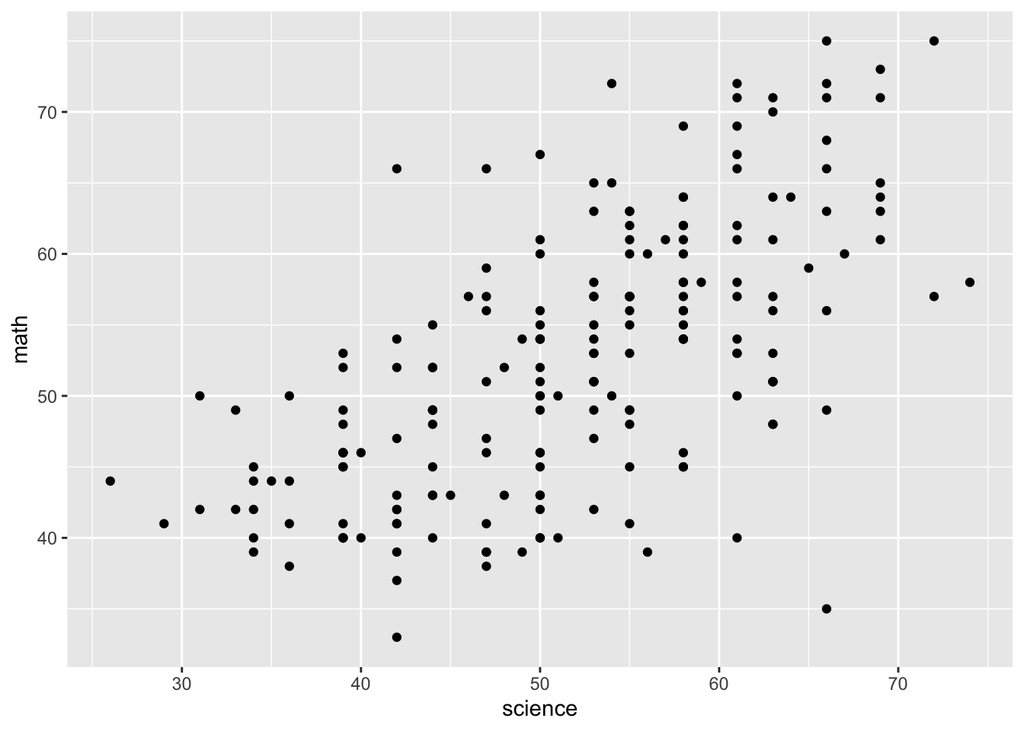

```r
ggplot(data = hsb2, aes(x = science, y =math)) +
  geom_point()
```

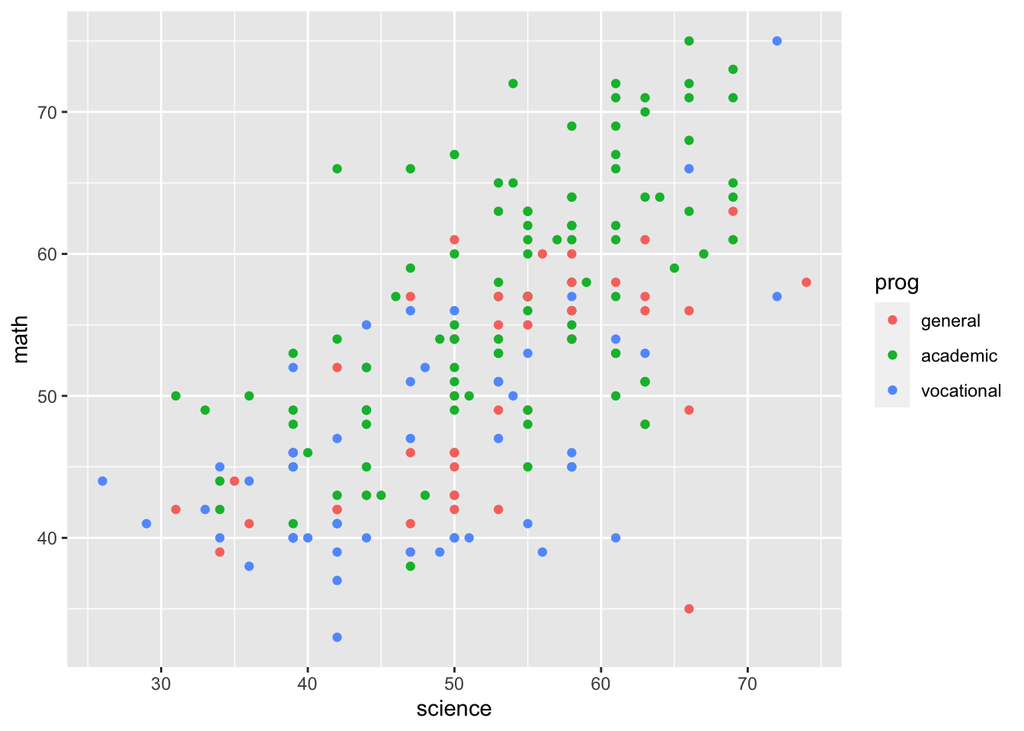

```r
ggplot(data = hsb2, aes(x = science, y = math, color = prog)) +
  geom_point()
```

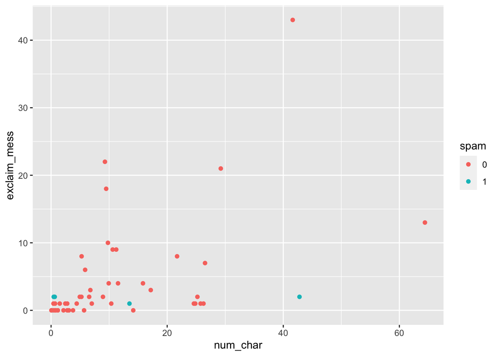

```r
email50 |>
  ggplot(aes(x = num_char, y = exclaim_mess, color = spam)) +
  geom_point()
```

```r
gapminder
```

```
## # A tibble: 1,704 × 6
##    country     continent  year lifeExp      pop gdpPercap
##    <fct>       <fct>     <int>   <dbl>    <int>     <dbl>
##  1 Afghanistan Asia       1952    28.8  8425333      779.
##  2 Afghanistan Asia       1957    30.3  9240934      821.
##  3 Afghanistan Asia       1962    32.0 10267083      853.
##  4 Afghanistan Asia       1967    34.0 11537966      836.
##  5 Afghanistan Asia       1972    36.1 13079460      740.
##  6 Afghanistan Asia       1977    38.4 14880372      786.
##  7 Afghanistan Asia       1982    39.9 12881816      978.
##  8 Afghanistan Asia       1987    40.8 13867957      852.
##  9 Afghanistan Asia       1992    41.7 16317921      649.
## 10 Afghanistan Asia       1997    41.8 22227415      635.
## # … with 1,694 more rows
```

Not considering an important variable when studying a relationship can result in what we call a *Simpson’s paradox*. This paradox illustrates the effect the omission of an explanatory variable can have on the measure of association between another explanatory variable and the response variable.

In other words, the inclusion of a third variable in the analysis can change the apparent relationship between the other 2 variables.

```r
data("county")

county_noDC <- county |>
  filter(state != "District of Columbia") |>
  droplevels()


county_srs <- county_noDC |>
  slice_sample(n=150)

glimpse(county_srs)
```

```
## Rows: 150
## Columns: 15
## $ name              <chr> "Brantley County", "Jackson County", "Mason County",…
## $ state             <fct> Georgia, Georgia, Kentucky, Pennsylvania, Arkansas, …
## $ pop2000           <dbl> 14629, 41589, 16800, 94643, 10996, 148677, 3996, 270…
## $ pop2010           <dbl> 18411, 60485, 17490, 91108, 11233, 185079, 4375, 282…
## $ pop2017           <int> 18731, 67519, 17174, 87069, 10445, 200381, 4740, 272…
## $ pop_change        <dbl> 2.71, 10.17, -0.90, -2.54, -4.24, 4.59, 0.38, -1.60,…
## $ poverty           <dbl> 21.8, 12.5, 18.0, 14.0, 20.5, 17.4, 11.8, 14.8, 22.0…
## $ homeownership     <dbl> 85.3, 75.2, 70.9, 78.1, 75.1, 66.2, 75.8, 76.9, 73.7…
## $ multi_unit        <dbl> 2.3, 5.7, 16.1, 12.7, 6.4, 20.9, 0.0, 12.8, 3.2, 1.1…
## $ unemployment_rate <dbl> 5.80, 3.64, 6.09, 6.09, 3.41, 2.81, 5.29, 5.39, 9.80…
## $ metro             <fct> yes, no, no, no, no, no, no, yes, no, yes, no, yes, …
## $ median_edu        <fct> hs_diploma, hs_diploma, hs_diploma, hs_diploma, hs_d…
## $ per_capita_income <dbl> 17397.45, 24879.66, 25232.27, 27220.51, 16957.74, 25…
## $ median_hh_income  <int> 36812, 57999, 43082, 47188, 37396, 56395, 63935, 407…
## $ smoking_ban       <fct> none, NA, NA, none, none, NA, none, partial, partial…
```

```r
county_srs |>
  group_by(state) |>
  count()
```

```
## # A tibble: 43 × 2
## # Groups:   state [43]
##    state           n
##    <fct>       <int>
##  1 Alabama         5
##  2 Alaska          1
##  3 Arkansas        4
##  4 California      3
##  5 Colorado        3
##  6 Connecticut     1
##  7 Florida         5
##  8 Georgia        15
##  9 Hawaii          1
## 10 Idaho           2
## # … with 33 more rows
```

```r
county_str <- county_noDC |>
  group_by(state) |>
  slice_sample(n=3)

glimpse(county_str)
```

```
## Rows: 150
## Columns: 15
## Groups: state [50]
## $ name              <chr> "Hale County", "Chambers County", "Shelby County", "…
## $ state             <fct> Alabama, Alabama, Alabama, Alaska, Alaska, Alaska, A…
## $ pop2000           <dbl> 17185, 36583, 143293, 1258, 6174, 82840, 33489, 1797…
## $ pop2010           <dbl> 15760, 34215, 195085, 997, 7029, 97581, 37220, 37577…
## $ pop2017           <int> 14812, 33713, 213605, 867, 6888, 99703, 37466, 43023…
## $ pop_change        <dbl> -2.86, -1.20, 4.76, -8.93, -1.32, -1.18, 0.13, 11.97…
## $ poverty           <dbl> 26.1, 18.8, 8.3, 7.1, 13.9, 7.7, 21.4, 15.5, 35.9, 2…
## $ homeownership     <dbl> 74.3, 71.4, 80.6, 56.6, 65.2, 59.8, 72.0, 77.7, 76.3…
## $ multi_unit        <dbl> 6.1, 8.7, 11.4, 13.4, 17.3, 26.2, 7.7, 6.3, 5.2, 12.…
## $ unemployment_rate <dbl> 5.89, 4.08, 3.23, 6.34, 10.44, 6.29, 5.44, 5.02, 10.…
## $ metro             <fct> yes, no, yes, no, no, yes, no, yes, no, no, yes, no,…
## $ median_edu        <fct> hs_diploma, hs_diploma, some_college, some_college, …
## $ per_capita_income <dbl> 19196.55, 21079.51, 34709.33, 38984.10, 24596.05, 34…
## $ median_hh_income  <int> 34679, 37342, 74063, 79500, 63866, 76250, 48173, 526…
## $ smoking_ban       <fct> none, none, NA, none, none, none, none, NA, NA, none…
```

```r
data("evals")

evals <- evals %>%
  mutate(cls_type = case_when(
    cls_students <= 18                      ~ "small",
    cls_students >= 19 & cls_students <= 59 ~ "midsize",
    cls_students >= 60                      ~ "large"
    )
  )

glimpse(evals)
```

```
## Rows: 463
## Columns: 24
## $ course_id     <int> 1, 2, 3, 4, 5, 6, 7, 8, 9, 10, 11, 12, 13, 14, 15, 16, 1…
## $ prof_id       <int> 1, 1, 1, 1, 2, 2, 2, 3, 3, 4, 4, 4, 4, 4, 4, 4, 4, 5, 5,…
## $ score         <dbl> 4.7, 4.1, 3.9, 4.8, 4.6, 4.3, 2.8, 4.1, 3.4, 4.5, 3.8, 4…
## $ rank          <fct> tenure track, tenure track, tenure track, tenure track, …
## $ ethnicity     <fct> minority, minority, minority, minority, not minority, no…
## $ gender        <fct> female, female, female, female, male, male, male, male, …
## $ language      <fct> english, english, english, english, english, english, en…
## $ age           <int> 36, 36, 36, 36, 59, 59, 59, 51, 51, 40, 40, 40, 40, 40, …
## $ cls_perc_eval <dbl> 55.81395, 68.80000, 60.80000, 62.60163, 85.00000, 87.500…
## $ cls_did_eval  <int> 24, 86, 76, 77, 17, 35, 39, 55, 111, 40, 24, 24, 17, 14,…
## $ cls_students  <int> 43, 125, 125, 123, 20, 40, 44, 55, 195, 46, 27, 25, 20, …
## $ cls_level     <fct> upper, upper, upper, upper, upper, upper, upper, upper, …
## $ cls_profs     <fct> single, single, single, single, multiple, multiple, mult…
## $ cls_credits   <fct> multi credit, multi credit, multi credit, multi credit, …
## $ bty_f1lower   <int> 5, 5, 5, 5, 4, 4, 4, 5, 5, 2, 2, 2, 2, 2, 2, 2, 2, 7, 7,…
## $ bty_f1upper   <int> 7, 7, 7, 7, 4, 4, 4, 2, 2, 5, 5, 5, 5, 5, 5, 5, 5, 9, 9,…
## $ bty_f2upper   <int> 6, 6, 6, 6, 2, 2, 2, 5, 5, 4, 4, 4, 4, 4, 4, 4, 4, 9, 9,…
## $ bty_m1lower   <int> 2, 2, 2, 2, 2, 2, 2, 2, 2, 3, 3, 3, 3, 3, 3, 3, 3, 7, 7,…
## $ bty_m1upper   <int> 4, 4, 4, 4, 3, 3, 3, 3, 3, 3, 3, 3, 3, 3, 3, 3, 3, 6, 6,…
## $ bty_m2upper   <int> 6, 6, 6, 6, 3, 3, 3, 3, 3, 2, 2, 2, 2, 2, 2, 2, 2, 6, 6,…
## $ bty_avg       <dbl> 5.000, 5.000, 5.000, 5.000, 3.000, 3.000, 3.000, 3.333, …
## $ pic_outfit    <fct> not formal, not formal, not formal, not formal, not form…
## $ pic_color     <fct> color, color, color, color, color, color, color, color, …
## $ cls_type      <chr> "midsize", "large", "large", "large", "midsize", "midsiz…
```

```r
evals <- evals |>
  mutate(
    cls_type = case_when(
      cls_students < 19 ~ 'small',
      19 <= cls_students & cls_students <= 59 ~ 'midsize',
      cls_students >= 60 ~ 'large'
    )
  )
```

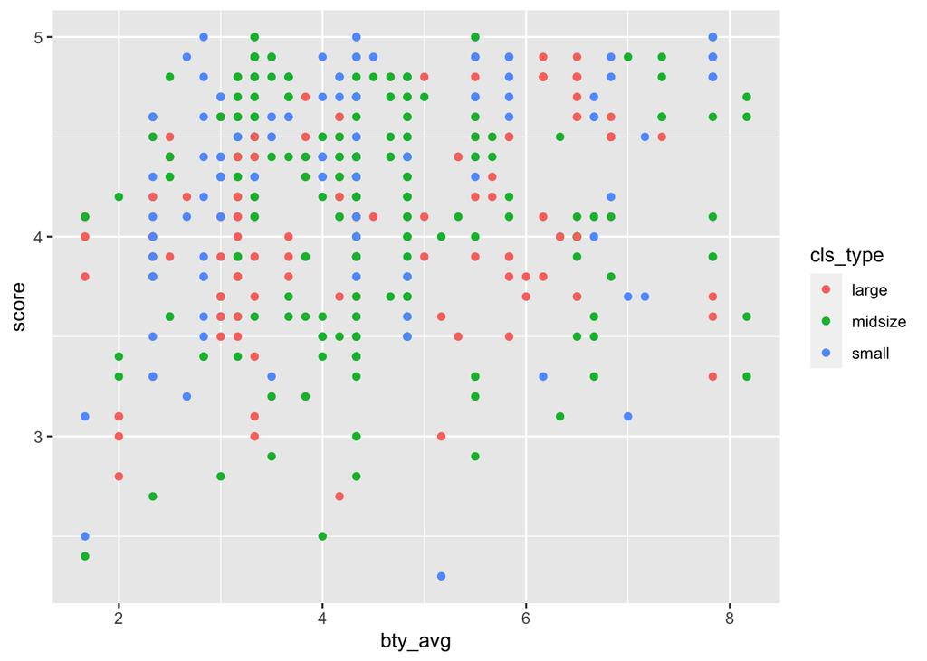

```r
evals |>
  ggplot(aes(x= bty_avg,
             y = score,
             color = cls_type)) +
  geom_point()
```